# outbreak.info R package

July 16, 2020

#### **getExactLocations**

**Description:**

Get iso3 codes for a country, state/province, county, and/or metro area.

**Usage:**

```r
getExactLocations(locations_to_search)
```

**Arguments:**

locations_to_search: a `vector` or `list` of location (country, state/province, county, metro area) names

**Example:**

```r
iso3=getExactLocations(c("Texas", "Brazil", "San Diego County"))
print(iso3)
```

```
## [1] "BRA"             "USA_US-CA_06073" "USA_US-TX"
```

#### **getLocationData**

**Description:**

Retrieve a `dataframe` of up-to-date COVID-19 data from [outbreak.info](https://outbreak.info/) for one or more countries, states/provinces, counties, and/or metro areas.

**Usage:**

```r
getLocationData(loc_names)
```

**Arguments:**

loc_names: a `vector` or `list` of location (country, state/province, county, metro area) names

**Example:**

```r
df=getLocationData(c("Texas", "Brazil", "San Diego County"))
head(df)
```

```
##              _id   _score admin_level confirmed confirmed_firstDate
## 1 BRA_2020-02-27 8.485011           0         1          2020-02-26
## 2 BRA_2020-03-03 8.485011           0         2          2020-02-26
## 3 BRA_2020-03-04 8.485011           0         4          2020-02-26
## 4 BRA_2020-03-09 8.485011           0        25          2020-02-26
## 5 BRA_2020-03-11 8.485011           0        38          2020-02-26
## 6 BRA_2020-03-14 8.485011           0       151          2020-02-26
##   confirmed_newToday confirmed_numIncrease confirmed_pctIncrease
## 1               TRUE                     0             0.0000000
## 2               TRUE                     0             0.0000000
## 3               TRUE                     2             1.0000000
## 4               TRUE                     5             0.2500000
## 5               TRUE                     7             0.2258065
## 6               TRUE                     0             0.0000000
##   confirmed_per_100k confirmed_rolling confirmed_rolling_per_100k country_name
```

[output cut: 174 more lines]

#### **getExactNames**

**Description:**

Get exact spelling of locations at the same administrative level.

**Usage:**

```r
getExactNames(locations_to_search, admin_level)
```

**Arguments:**

locations_to_search: a `vector` or `list` of location names at the same administrative level

admin_level: an `integer` representing an administrative level (countries = 0, states/provinces = 1, metro areas = 1.5, counties = 2)

**Example:**

```r
names=getExactNames(c("California", "Florida", "Texas"), admin_level=1)
print(names)
```

```
## [1] "Florida"    "California" "Texas"
```

#### **getAdmn2Data**

**Description:**

Retrieve a `dataframe` of up-to-date COVID-19 data from [outbreak.info](https://outbreak.info/) for all counties in a state or states.

**Usage:**

```r
getAdmn2Data(states_of_interest)
```

**Arguments:**

states_of_interest: a `vector` or `list` of state names

**Example:**

```r
countydf=getAdmn2Data("California")
print(unique(countydf$name))
```

```
##  [1] "Alameda County"         "Alpine County"          "Amador County"
##  [4] "Butte County"           "Calaveras County"       "Colusa County"
##  [7] "Contra Costa County"    "Del Norte County"       "El Dorado County"
## [10] "Fresno County"          "Glenn County"           "Humboldt County"
## [13] "Imperial County"        "Inyo County"            "Kern County"
## [16] "Kings County"           "Lake County"            "Lassen County"
## [19] "Los Angeles County"     "Madera County"          "Marin County"
## [22] "Mariposa County"        "Mendocino County"       "Merced County"
## [25] "Mono County"            "Monterey County"        "Napa County"
## [28] "Nevada County"          "Orange County"          "Placer County"
## [31] "Plumas County"          "Riverside County"       "Sacramento County"
## [34] "San Benito County"      "San Bernardino County"  "San Diego County"
## [37] "San Francisco County"   "San Joaquin County"     "San Luis Obispo County"
## [40] "San Mateo County"       "Santa Barbara County"   "Santa Clara County"
## [43] "Santa Cruz County"      "Shasta County"          "Sierra County"
## [46] "Siskiyou County"        "Solano County"          "Sonoma County"
## [49] "Stanislaus County"      "Sutter County"          "Tehama County"
## [52] "Trinity County"         "Tulare County"          "Tuolumne County"
## [55] "Ventura County"         "Yolo County"            "Yuba County"
```

#### **plotCases**

**Description:**

Plot cases using up-to-date COVID-19 cases using data from [outbreak.info](https://outbreak.info/) for location(s) of interest (country, state/province, county, metro area)

**Usage:**

```r
plotCases(locs)
```

**Arguments:**

locs: a `vector` or `list` of location(s) of interest

**Example:**

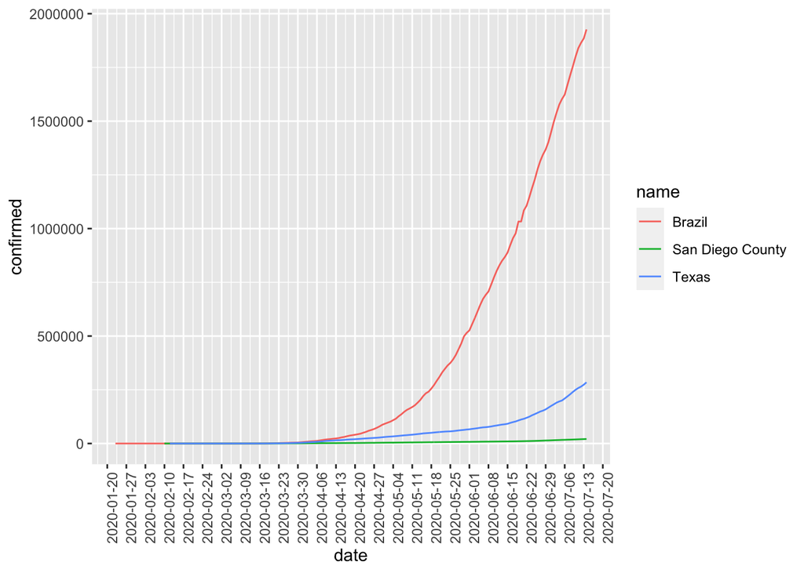

```r
plotCases(c("Texas", "Brazil", "San Diego County"))
```

#### **plotCasesPer100k**

**Description:**

Plot cases using up-to-date COVID-19 cases per 100,000 using data from [outbreak.info](https://outbreak.info/) for location(s) of interest (country, state/province, county, metro area)

**Usage:**

```r
plotCasesPer100k(locs)
```

**Arguments:**

locs: a `vector` or `list` of location(s) of interest

**Example:**

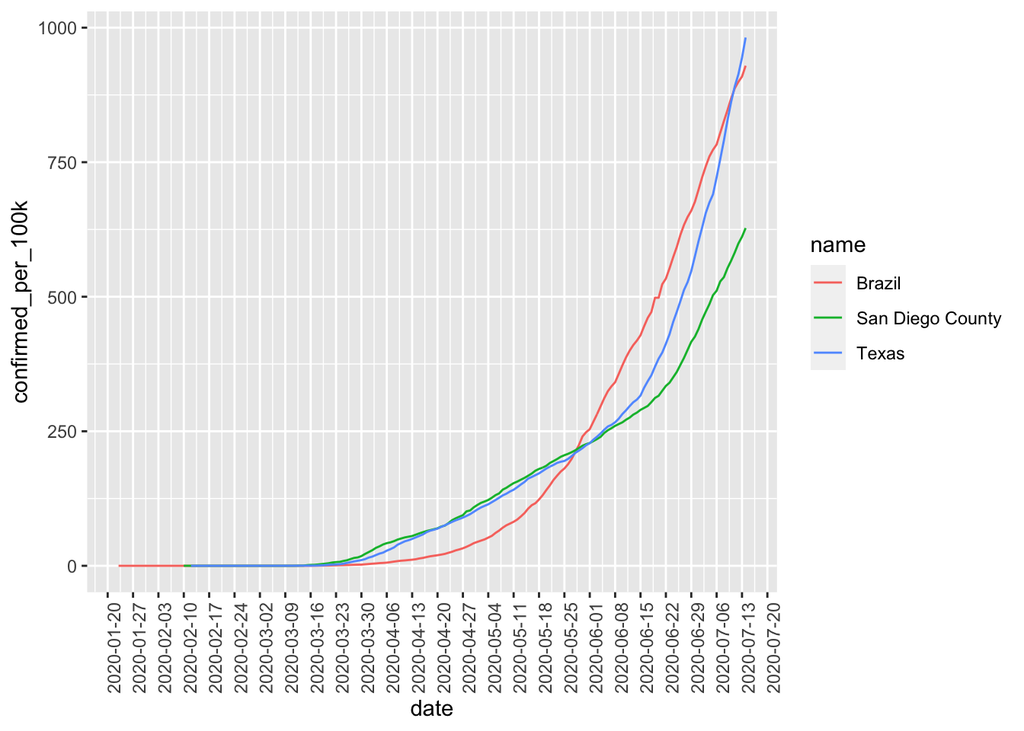

```r
plotCasesPer100k(c("Texas", "Brazil", "San Diego County"))
```